# Porfolio 7 - Graphing Study 2

Adam

5/5/2022

> The goal of this portfolio is to create graphs to display the findings from Study 2.

## Setting up

```r
library('reshape2')
library('ggplot2')
library('dplyr')
library('Rcpp')
library('readr')
library('tidyverse')
library('psych')
library('emmeans')
```

### Bringing in the data

```r
study1 <- read_csv("Study2_data_R_cleaned.csv")

# Ensuring the dataframe is a tibble.
as_tibble(study1)
```

```
## # A tibble: 140 x 141
##    Finished.x participant_id manip_interest manip_personal manip_encourage
##         <dbl> <chr>                   <dbl>          <dbl>           <dbl>
##  1          1 102A                        4              4               4
##  2          1 102B                        4              2               2
##  3          1 102C                        3              2               2
##  4          1 102D                        4              3               2
##  5          1 103A                        4              1               2
##  6          1 103B                        3              1               1
##  7          1 103C                        2              2               2
##  8          1 104A                        3              2               4
##  9          1 104B                        2              4               4
## 10          1 104C                        3              3               4
## # ... with 130 more rows, and 136 more variables: manip_help_think <dbl>,
## #   manip_represent <dbl>, manip_suprise <dbl>, group_talk <dbl>,
## #   group_engage <dbl>, group_enjoy <dbl>, group_fun <dbl>, self_close <dbl>,
## #   self_like <dbl>, group_like <dbl>, group_tell <dbl>, group_share <dbl>,
## #   group_honest <dbl>, self_learn_about <dbl>, self_tell <dbl>,
## #   self_share <dbl>, self_honest <dbl>, group_learn_about <dbl>,
## #   IOS_slider_1 <dbl>, know_prior_study <dbl>, study_partic_total <dbl>, ...
```

```r
#Taking a look at the table.
View(study1)
```

The code below subsets the data that I’m working with only to the parts I’m interested in. As well, it renames the condition variable to be easier to understand, and ensures that it is a factor.

```r
study1_graph <- study1 %>%
        select(class_belong_comp4, school_belong_comp4, motiv_intrins_comp2, motiv_util_comp3, close_comp3, quiz_average,  condition)

study1_graph$condition = factor(study1_graph$condition,
                                levels = c(0,1,2),
                                labels = c("Control", "Prompted discussion", "Prompted disclosure")
                                )
```

## Creating graphs

I want to create bar graphs for each of the variables of interest. We created graphs that I used for my thesis, so my goal is going to be to recreate those. Specifically; Closeness, Institutional belonging, Class belonging, Intrinsic motivation, Utility motivation, and Quiz performance.

I will be using a lot of code in my graphs, so I’ve gone and made some shortcuts to plug in as I go. This idea was taken from the Youtube channel “Statistics of Doom”. The point is to save me a lot of extra code typing that I could mess up, and to make the code look a little nicer.

```r
vis_col =
  scale_fill_manual(values = c( #Color codes for the conditions.
    "Control" = "#fece3d",
    "Prompted discussion" = "#fd8d3c",
    "Prompted disclosure" = "#31a354"))

vis_theme =  theme(panel.background = element_blank(), #makes the background invisible
                   panel.grid.major.y = element_line(color = "#DAE1E7"), #makes the y-axis gridlines appear, but not x-axis
axis.line = element_line(color = "black")) #makes the axis appear in a dark black color

vis_text =     theme( #trbl are the margin signs, top, right, bottom, left
    plot.title = element_text(size = 20, margin = margin(b = 5)),
    plot.subtitle = element_text(size = 12, margin = margin(b= 10)),
    axis.text = element_text(size = 12),
    axis.title = element_text(size = 16, hjust = 1),
    axis.title.x = element_text(margin = margin(t = 10)),
    axis.title.y = element_text(margin = margin(r = 10)),
    axis.text.y = element_text(margin = margin(r = 5)),
    axis.text.x = element_text(margin = margin(t = 5)),
  )
```

### Closeness

Below was the first successful version of the graph that I made. Very basic. Also, very wrong.

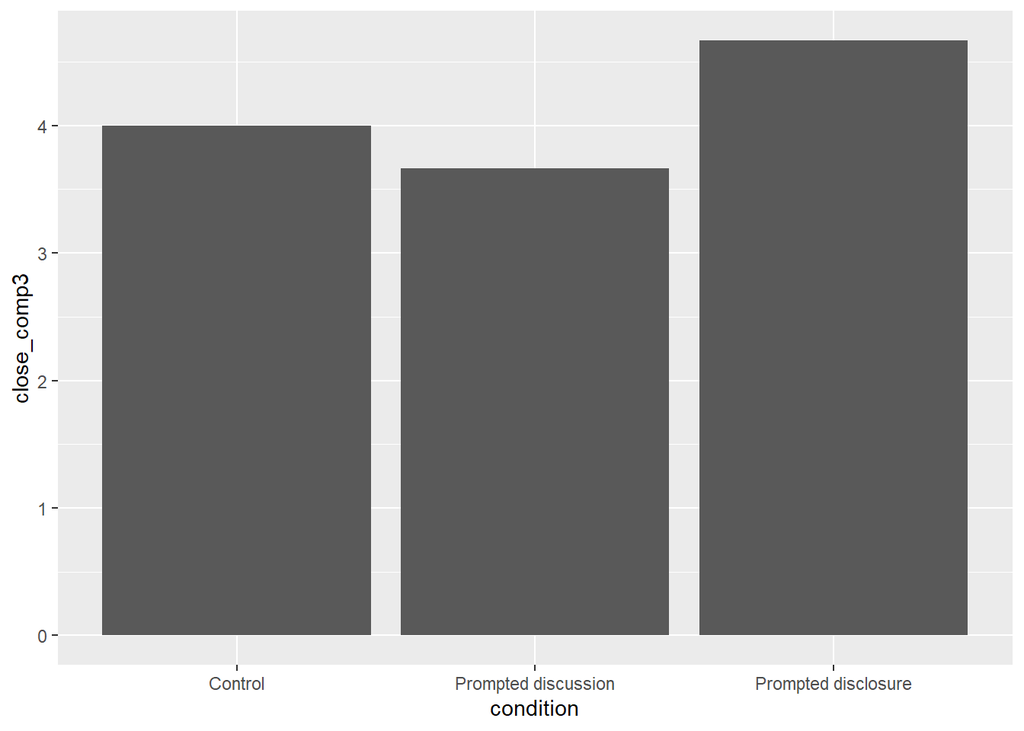

```r
ggplot(data = study1_graph, mapping = aes(x = condition, y= close_comp3)) +
  geom_bar(position= position_dodge(), stat= 'identity')
```

After a lot of iteration, I got to this. The code is much more complex, and it pretty closely mirrors the graphs we actually used in my thesis. Explanations of the code are in-line.

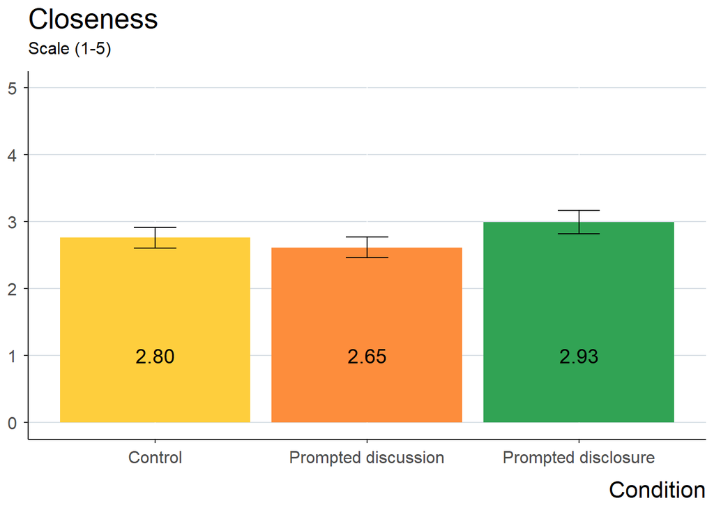

```r
ggplot(data = study1_graph, aes(x = condition, y= close_comp3, fill = condition)) + #Fill is starting the color code nonsense
  stat_summary(fun = mean, geom= "bar") + #This is making it measure the mean on the y-axis
  stat_summary(fun.data = mean_cl_normal, geom= "errorbar", width =.2, inherit.aes = TRUE)+ #mean_cl_normal and geom are making the error bars appear, inherit.aes makes it copy the aes from the beginning, e.g, fill
  guides(fill = FALSE) + # Allows the aes colors to be done manually.
  scale_y_continuous(limits = c(0, 5)) + #Affixes the scale to the full range of the measure
  vis_col + #This, vis_theme, and vis_text are shortcuts. See above.
  vis_theme +
  labs(x = "Condition",
  y= NULL,
  title= "Closeness",
  subtitle= "Scale (1-5)") + # The terminology for the labels
  annotate("text", x="Control", y=1, label= "2.80", size=5) + #these lines add the means to the graph
  annotate("text", x= "Prompted discussion", y=1, label= "2.65", size=5) +
  annotate("text", x= "Prompted disclosure", y=1, label= "2.93", size=5) +
  vis_text
```

For the next graphs, I am wantonly stealing this code and making the modifications for each variable.

### School belonging

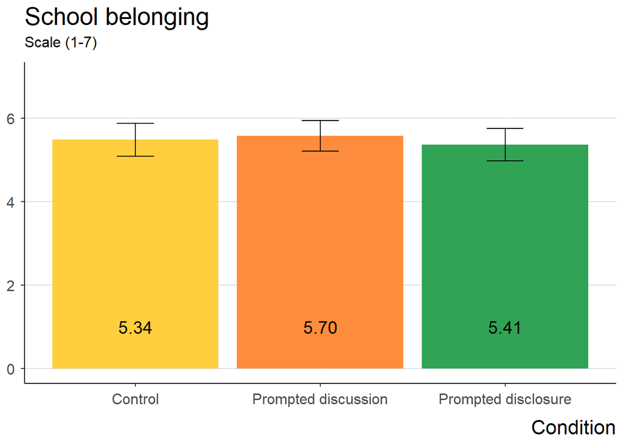

```r
ggplot(data = study1_graph, mapping = aes(x = condition, y= school_belong_comp4, fill = condition)) +
  stat_summary(fun = mean, geom= "bar") +
  stat_summary(fun.data = mean_cl_normal, geom= "errorbar", width =.2, inherit.aes = TRUE)+
  guides(fill = FALSE) +
  scale_y_continuous(limits = c(0, 7)) +
  vis_col +
  vis_theme +
  labs(x = "Condition",
  y= NULL,
  title= "School belonging",
  subtitle= "Scale (1-7)") +
  annotate("text", x="Control", y=1, label= "5.34", size=5) +
  annotate("text", x= "Prompted discussion", y=1, label= "5.70", size=5) +
  annotate("text", x= "Prompted disclosure", y=1, label= "5.41", size=5) +
  vis_text
```

### Class belonging

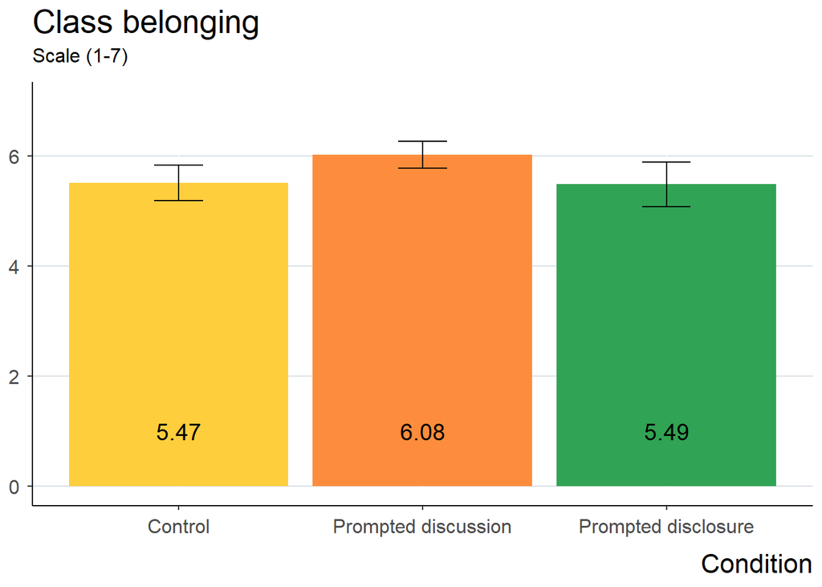

```r
ggplot(data = study1_graph, mapping = aes(x = condition, y= class_belong_comp4, fill = condition)) +
  stat_summary(fun = mean, geom= "bar") +
  stat_summary(fun.data = mean_cl_normal, geom= "errorbar", width =.2, inherit.aes = TRUE)+
  guides(fill = FALSE) +
  scale_y_continuous(limits = c(0, 7)) +
  vis_col +
  vis_theme +
  labs(x = "Condition",
  y= NULL,
  title= "Class belonging",
  subtitle= "Scale (1-7)") +
  annotate("text", x="Control", y=1, label= "5.47", size=5) +
  annotate("text", x= "Prompted discussion", y=1, label= "6.08", size=5) +
  annotate("text", x= "Prompted disclosure", y=1, label= "5.49", size=5) +
  vis_text
```

### Intrinsic motivation

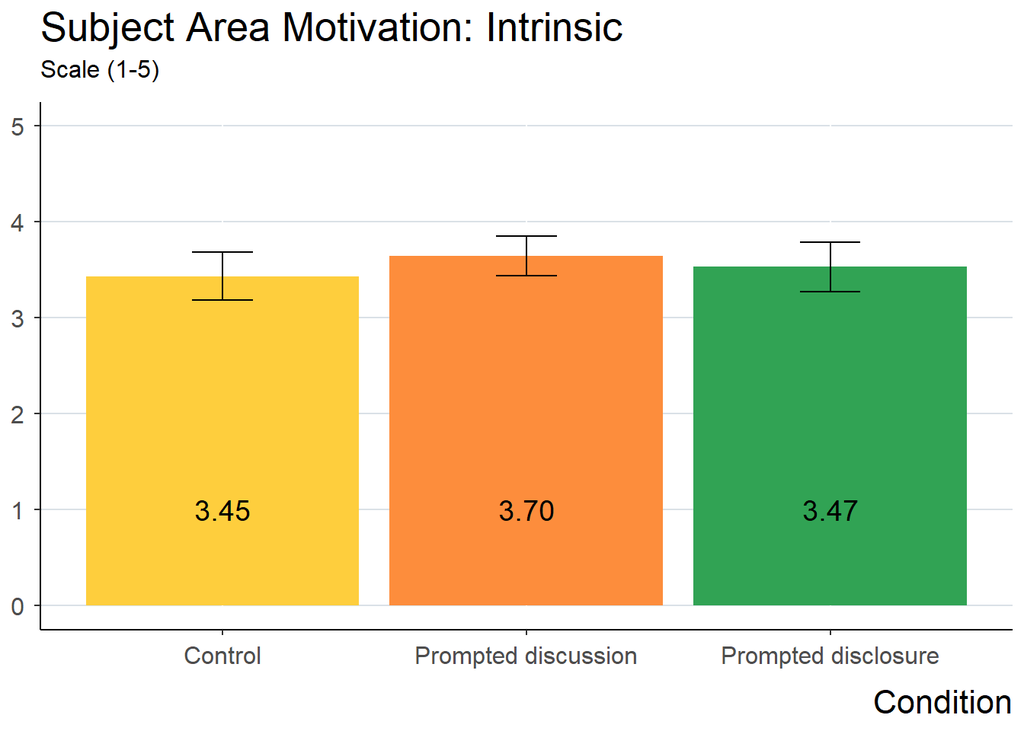

```r
ggplot(data = study1_graph, mapping = aes(x = condition, y= motiv_intrins_comp2, fill = condition)) +
  stat_summary(fun = mean, geom= "bar") +
  stat_summary(fun.data = mean_cl_normal, geom= "errorbar", width =.2, inherit.aes = TRUE)+
  guides(fill = FALSE) +
  scale_y_continuous(limits = c(0, 5)) +
  vis_col +
  vis_theme +
  labs(x = "Condition",
  y= NULL,
  title= "Subject Area Motivation: Intrinsic",
  subtitle= "Scale (1-5)") +
  annotate("text", x="Control", y=1, label= "3.45", size=5) +
  annotate("text", x= "Prompted discussion", y=1, label= "3.70", size=5) +
  annotate("text", x= "Prompted disclosure", y=1, label= "3.47", size=5) +
  vis_text
```

### Utility motivation

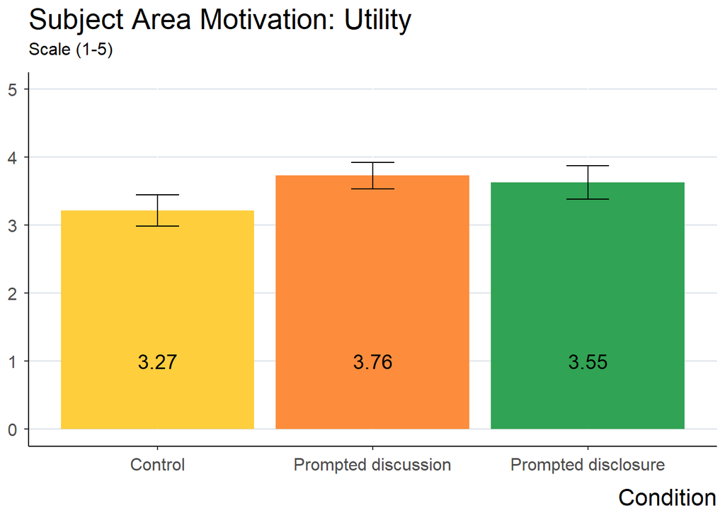

```r
ggplot(data = study1_graph, mapping = aes(x = condition, y= motiv_util_comp3, fill = condition)) +
  stat_summary(fun = mean, geom= "bar") +
  stat_summary(fun.data = mean_cl_normal, geom= "errorbar", width =.2, inherit.aes = TRUE)+
  guides(fill = FALSE) +
  scale_y_continuous(limits = c(0, 5)) +
  vis_col +
  vis_theme +
  labs(x = "Condition",
  y= NULL,
  title= "Subject Area Motivation: Utility",
  subtitle= "Scale (1-5)") +
  annotate("text", x="Control", y=1, label= "3.27", size=5) +
  annotate("text", x= "Prompted discussion", y=1, label= "3.76", size=5) +
  annotate("text", x= "Prompted disclosure", y=1, label= "3.55", size=5) +
  vis_text
```

### Quiz performance

This one required a change to the scale, since it is a grade, meaning the scale needed to run from 0 to .9

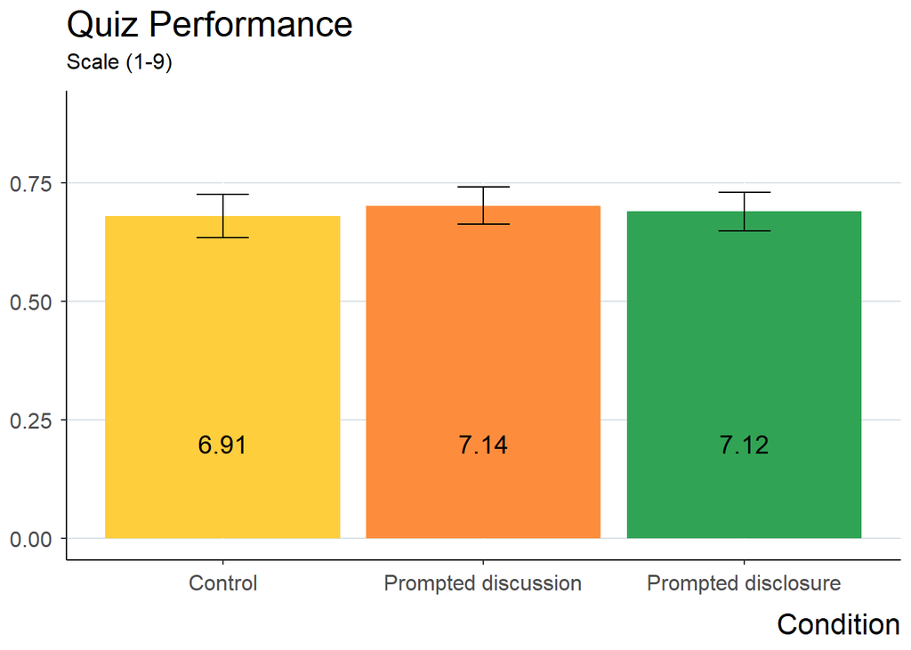

```r
ggplot(data = study1_graph, mapping = aes(x = condition, y= quiz_average, fill = condition)) +
  stat_summary(fun = mean, geom= "bar") +
  stat_summary(fun.data = mean_cl_normal, geom= "errorbar", width =.2, inherit.aes = TRUE)+
  guides(fill = FALSE) +
  scale_y_continuous(limits = c(0, .9)) +
  vis_col +
  vis_theme +
  labs(x = "Condition",
  y= NULL,
  title= "Quiz Performance",
  subtitle= "Scale (1-9)") +
  annotate("text", x="Control", y=.20, label= "6.91", size=5) +
  annotate("text", x= "Prompted discussion", y=.20, label= "7.14", size=5) +
  annotate("text", x= "Prompted disclosure", y=.20, label= "7.12", size=5) +
  vis_text
```

## Finishing up

This code served as an excellent test-bed in making graphs in a way different from what we have done in class, and also showed me about piping in code that I wrote myself.